# Data visualization using R base graphics

## Overview of R graphics systems

R has two graphics systems implemented in the R base package **graphics** and the **grid** package. See [An Introduction to R Graphics] (https://www.stat.auckland.ac.nz/~paul/RGraphics/chapter1.pdf). **ggplot2** is the most popular package for data visualization.

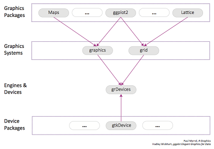

## A quick view of data visualization

### Creating a Graph

In R, graphs are typically created interactively.

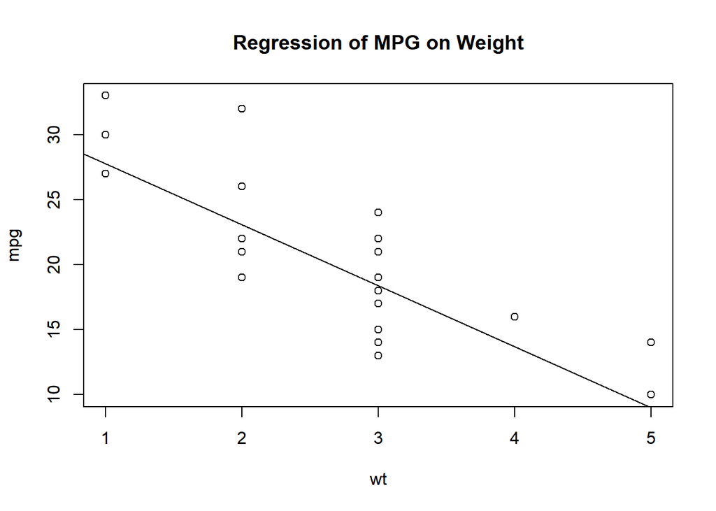

```r
# Creating a Graph
suppressMessages(attach(mtcars))
plot(wt, mpg)
abline(lm(mpg~wt))
title("Regression of MPG on Weight")
```

The plot( ) function opens a graph window and plots weight vs. miles per gallon. The next line of code adds a regression line to this graph. The final line adds a title.

### Saving Graphs

You can also save the graph via code using one of the following functions.

| Function | Output to |
| --- | --- |
| pdf(“mygraph.pdf”) | pdf file |
| png(“mygraph.png”) | png file |
| jpeg(“mygraph.jpg”) | jpeg file |
| bmp(“mygraph.bmp”) | bmp file |

### Viewing Several Graphs

Creating a new graph by issuing a high level plotting command (plot, hist, boxplot, etc.) will typically overwrite a previous graph. To avoid this, open a new graph window before creating a new graph. To open a new graph window use one of the functions below. Rstudio can keep multiple graphs in the **“Plots”** tab.

| Function | Platform |
| --- | --- |
| windows() | Windows |
| X11() | Unix |
| quartz() | Mac |

You can have multiple graph windows open at one time. See help(dev.cur) for more details.

### Graphical Parameters

You can specify fonts, colors, line styles, axes, reference lines, etc, by specifying graphical parameters. This allows a wide degree of customization.

## Base Graphics System

### Histograms and Density Plots

1. Histograms  
   You can create histograms with the function hist(x) where x is a numeric vector of values to be plotted. The option freq = FALSE plots probability densities instead of frequencies. The option breaks = controls the number of bins.

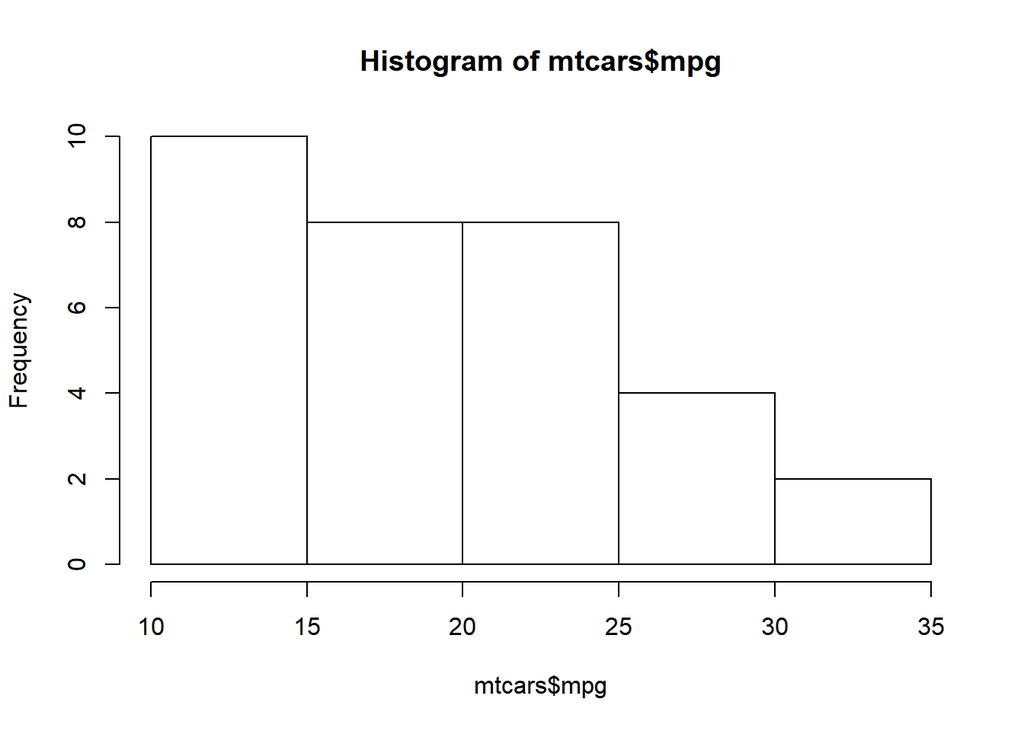

```r
#Simple Histogram
hist(mtcars$mpg)
```

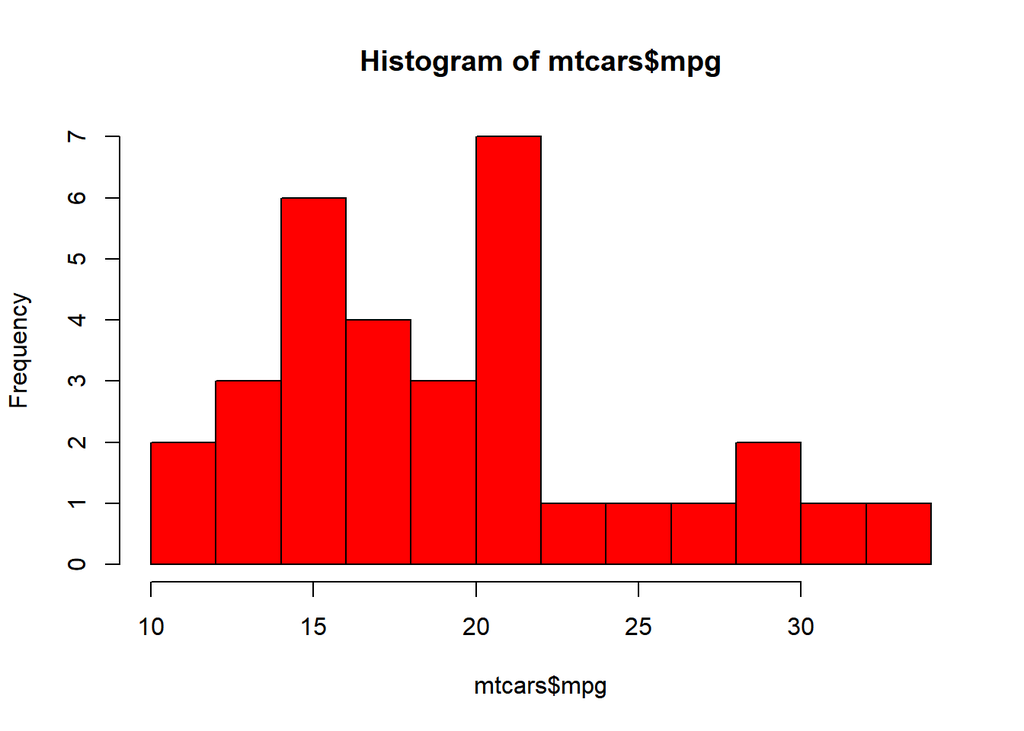

```r
# Colored Histogram with Different Number of Bins
hist(mtcars$mpg, breaks = 12, col = "red")
```

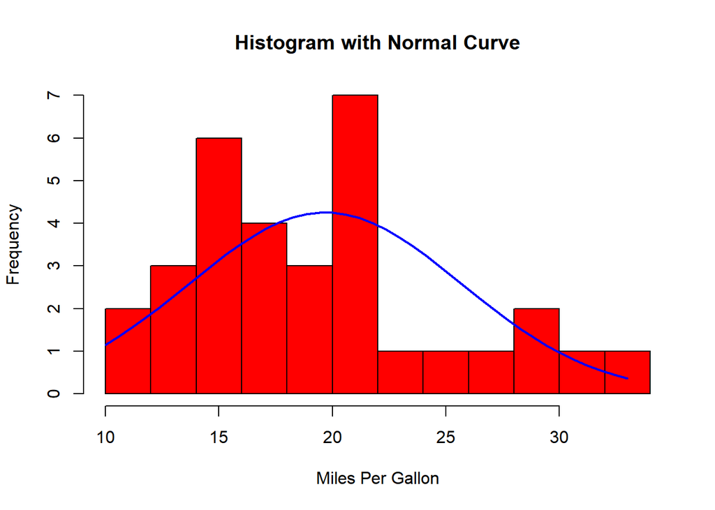

```r
# Add a Normal Curve
x <- mtcars$mpg
h <- hist(
  x,
  breaks = 10,
  col = "red",
  xlab = "Miles Per Gallon",
  main = "Histogram with Normal Curve"
)
xfit <- seq(min(x), max(x), length = 40)
# density
yfit <- dnorm(xfit, mean = mean(x), sd = sd(x))

# Frequency
yfit <- yfit * diff(h$mids[1:2]) * length(x)
lines(xfit, yfit, col = "blue", lwd = 2)
```

Histograms can be a poor method for determining the shape of a distribution because it is so strongly affected by the number of bins used.

2. Kernel Density Plots  
   Kernel density plots are usually a much more effective way to view the distribution of a variable. Create the plot using plot(density(x)) where x is a numeric vector.

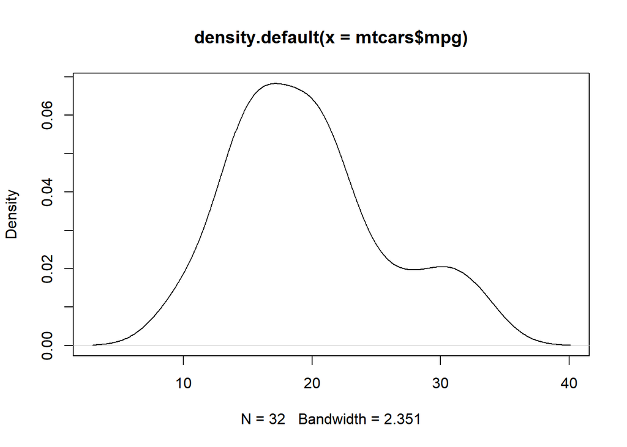

```r
# Kernel Density Plot
d <- density(mtcars$mpg) # returns the density data
plot(d) # plots the results
```

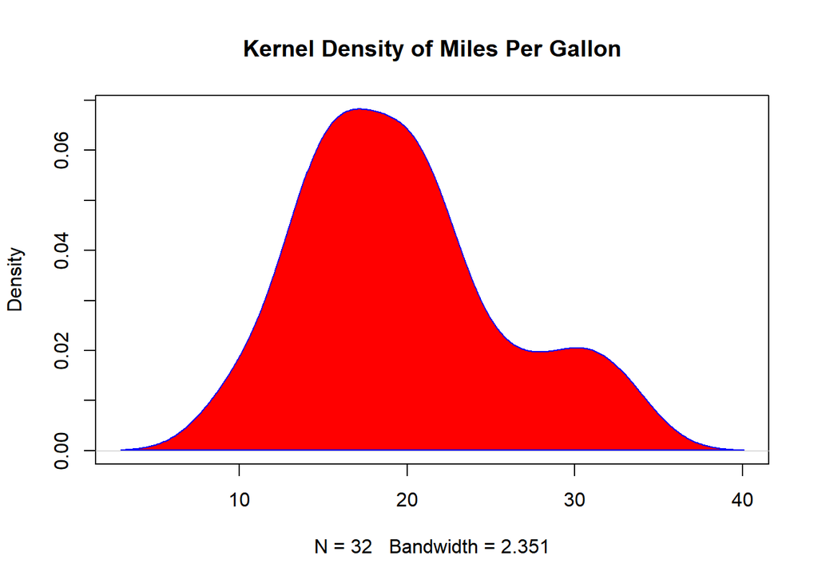

```r
# Filled Density Plot
d <- density(mtcars$mpg)
plot(d, main = "Kernel Density of Miles Per Gallon")
polygon(d, col = "red", border = "blue")
```

3. Comparing Groups Via Kernel Density  
   The sm.density.compare( ) function in the sm package allows you to superimpose the kernel density plots of two or more groups. The format is sm.density.compare(x, factor) where x is a numeric vector and factor is the grouping variable.

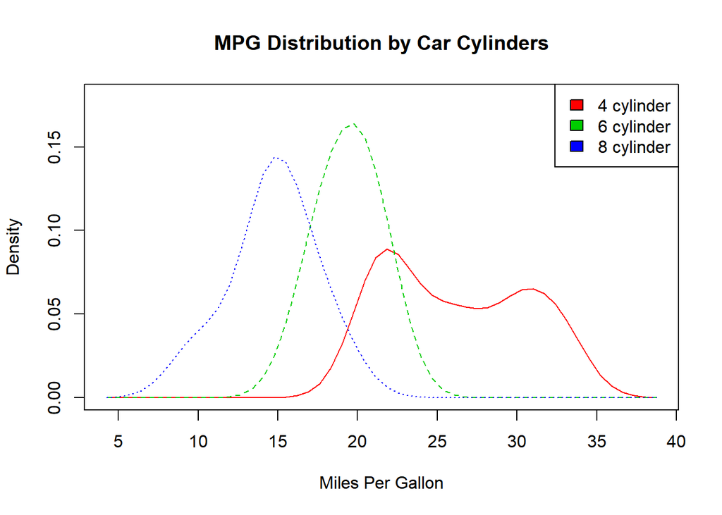

```r
# Compare MPG distributions for cars with
# 4,6, or 8 cylinders
library(sm)
# create value labels
cyl.f <- factor(cyl, levels = c(4,6,8),
  labels = c("4 cylinder", "6 cylinder", "8 cylinder"))

# plot densities
sm.density.compare(mpg, cyl, xlab = "Miles Per Gallon")
title(main = "MPG Distribution by Car Cylinders")

# add legend
colfill <- c(2:(2 + length(levels(cyl.f))))
 legend("topright", levels(cyl.f), fill = colfill)
```

### Dot Plots

Create dotplots with the dotchart(x, labels = ) function, where x is a numeric vector and labels is a vector of labels for each point. You can add a groups = option to designate a factor specifying how the elements of x are grouped. If so, the option gcolor = controls the color of the groups label. cex controls the size of the labels.

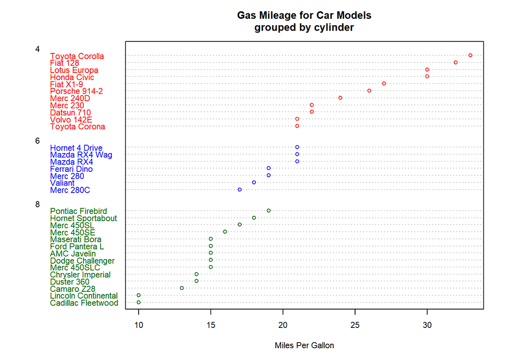

```r
# Dotplot: Grouped Sorted and Colored
# Sort by mpg, group and color by cylinder
x <- mtcars[order(mtcars$mpg),] # sort by mpg
x$cyl <- factor(x$cyl) # it must be a factor
x$color[x$cyl == 4] <- "red"
x$color[x$cyl == 6] <- "blue"
x$color[x$cyl == 8] <- "darkgreen"
dotchart(x$mpg,labels = row.names(x),cex = .7,groups =  x$cyl,
   main = "Gas Mileage for Car Models\ngrouped by cylinder",
   xlab = "Miles Per Gallon", gcolor = "black", color = x$color)
```

Advanced dotplots can be created with the dotplot2( ) function in the Hmisc package and with the panel.dotplot( ) function in the lattice package.

### Bar Plots

Create barplots with the barplot(height) function, where height is a vector or matrix. If height is a vector, the values determine the heights of the bars in the plot. If height is a matrix and the option beside = FALSE then each bar of the plot corresponds to a column of height, with the values in the column giving the heights of stacked sub-bars. If height is a matrix and beside = TRUE, then the values in each column are juxtaposed rather than stacked. Include option names.arg = (character vector) to label the bars. The option horiz = TRUE to create a horizontal barplot.

1. Simple bar plot

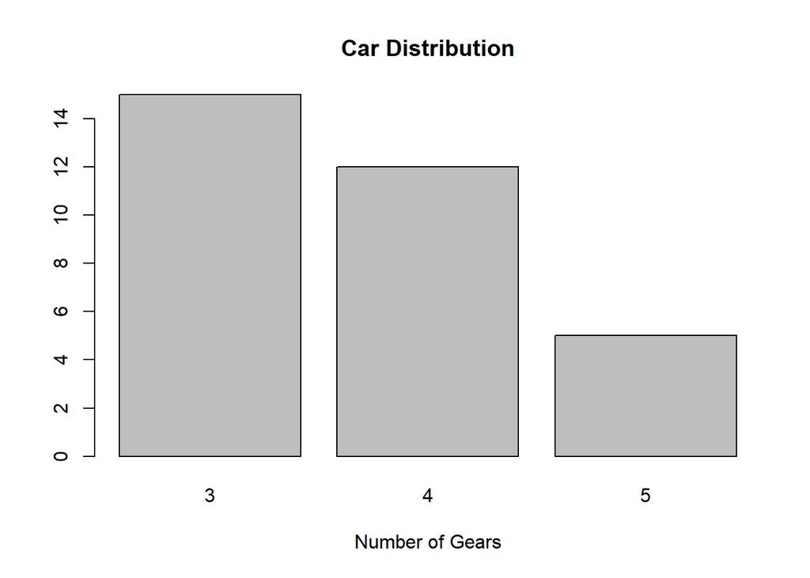

```r
# Simple Bar Plot
counts <- table(mtcars$gear)
barplot(counts, main = "Car Distribution",
   xlab = "Number of Gears")
```

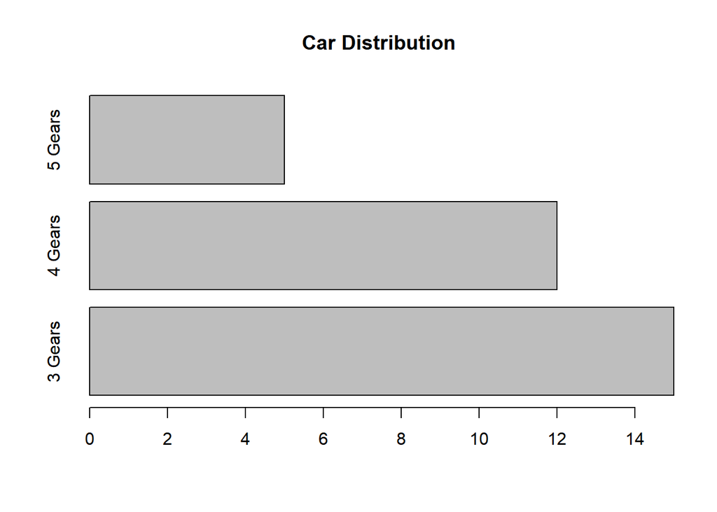

```r
# Simple Horizontal Bar Plot with Added Labels
counts <- table(mtcars$gear)
barplot(counts, main = "Car Distribution", horiz = TRUE,
  names.arg = c("3 Gears", "4 Gears", "5 Gears"))
```

2. Stacked Bar Plot

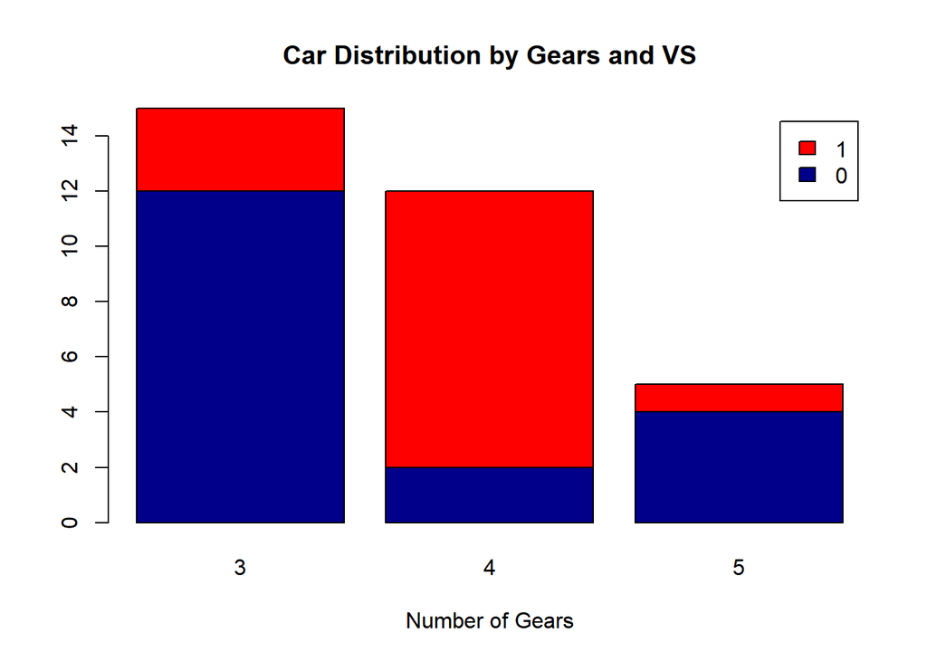

```r
# Stacked Bar Plot with Colors and Legend
counts <- table(mtcars$vs, mtcars$gear)
barplot(counts, main = "Car Distribution by Gears and VS",
  xlab = "Number of Gears", col = c("darkblue","red"),
  legend = rownames(counts))
```

3. Grouped Bar Plots

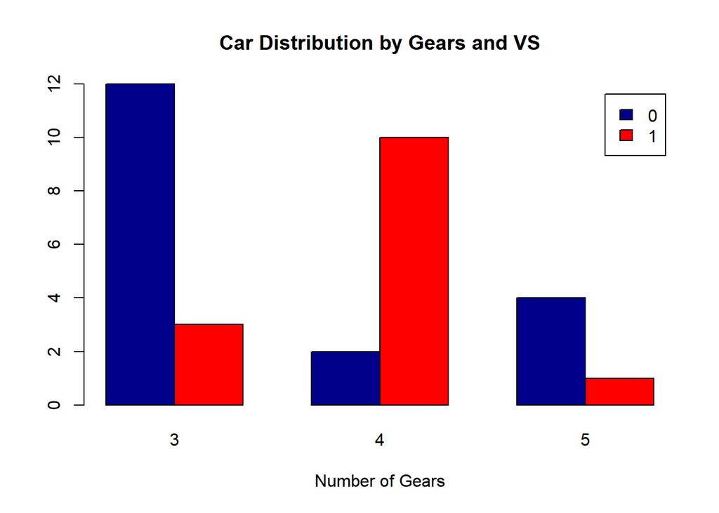

```r
# Grouped Bar Plot
counts <- table(mtcars$vs, mtcars$gear)
barplot(counts, main = "Car Distribution by Gears and VS",
  xlab = "Number of Gears", col = c("darkblue","red"),
  legend = rownames(counts), beside = TRUE)
```

### Line charts

The lines( ) function adds information to a graph. It can not produce a graph on its own. Usually it follows a plot(x, y) command that produces a graph.

By default, plot( ) plots the (x,y) points. Use the type = “n” option in the plot( ) command, to create the graph with axes, titles, etc., but without plotting the points.

Line charts are created with the function lines(x, y, type = ) where x and y are numeric vectors of (x,y) points to connect. type = can take the following values:

| Type | Description |
| --- | --- |
| p | points |
| l | lines |
| o | overplotted points and lines |
| b, c | points (empty if “c”) joined by lines |
| s, S | stair steps |
| h | histogram-like vertical lines |
| n | does not produce any points or lines |

Next, we demonstrate each of the type = options when plot( ) sets up the graph and does plot the points.

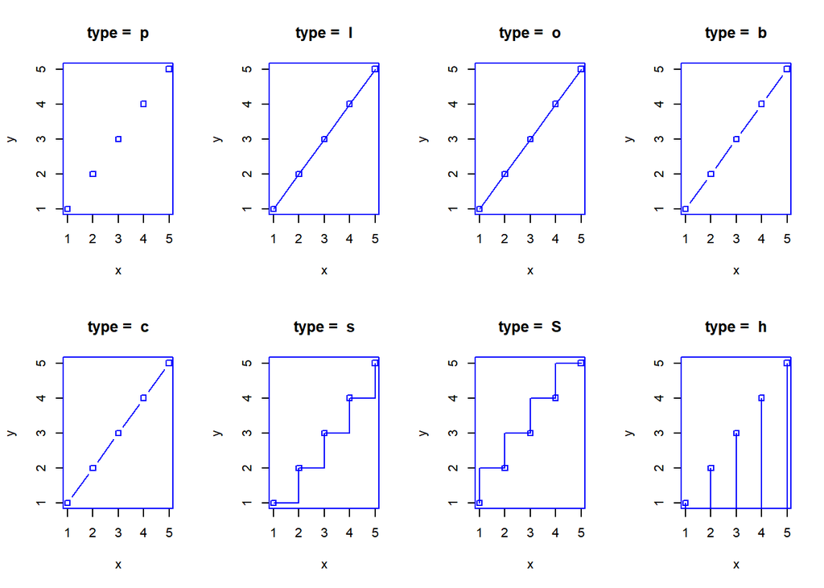

```r
x <- c(1:5); y <- x # create some data
par(pch = 22, col = "blue") # plotting symbol and color
par(mfrow = c(2,4)) # all plots on one page
opts =  c("p","l","o","b","c","s","S","h")
for (i in 1:length(opts)){
  heading =  paste("type = ",opts[i])
  plot(x, y, main = heading)
  lines(x, y, type = opts[i])
}
```

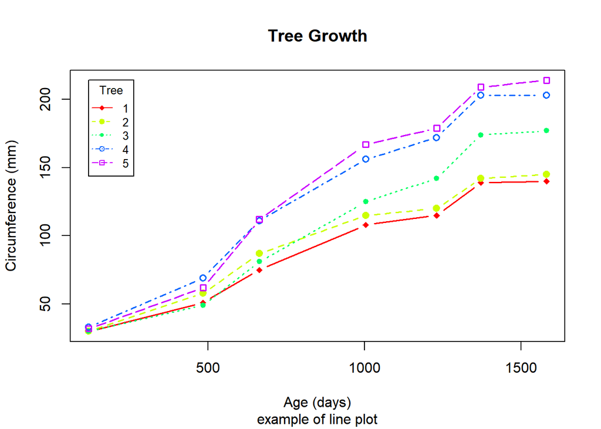

```r
# Create Line Chart
# convert factor to numeric for convenience
Orange$Tree <- as.numeric(Orange$Tree)
ntrees <- max(Orange$Tree)

# get the range for the x and y axis
xrange <- range(Orange$age)
yrange <- range(Orange$circumference)

# set up the plot
plot(xrange, yrange, type = "n", xlab = "Age (days)",
   ylab = "Circumference (mm)" )
colors <- rainbow(ntrees)
linetype <- c(1:ntrees)
plotchar <- seq(18,18+ntrees,1)

# add lines
for (i in 1:ntrees) {
  tree <- subset(Orange, Tree == i)
  lines(tree$age, tree$circumference, type = "b", lwd = 1.5,
    lty = linetype[i], col = colors[i], pch = plotchar[i])
}

# add a title and subtitle
title("Tree Growth", "example of line plot")

# add a legend
legend(xrange[1], yrange[2], 1:ntrees, cex = 0.8, col = colors,
   pch = plotchar, lty = linetype, title = "Tree")
```

### Boxplots

Boxplots can be created for individual variables or for variables by group. The format is boxplot(x, data = ), where x is a formula and data = denotes the data frame providing the data. An example of a formula is y~group where a separate boxplot for numeric variable y is generated for each value of group. Add varwidth = TRUE to make boxplot widths proportional to the square root of the samples sizes. Add horizontal = TRUE to reverse the axis orientation.

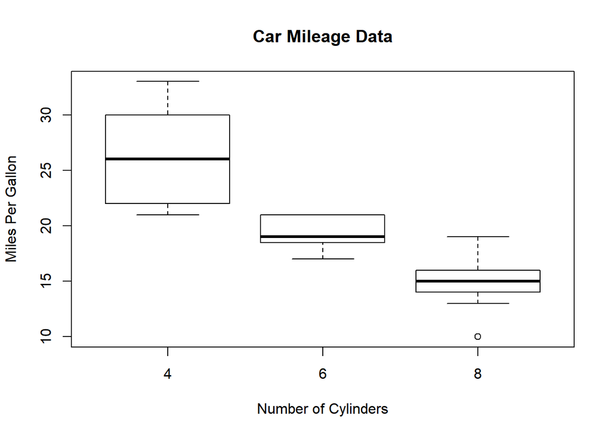

```r
# Boxplot of MPG by Car Cylinders
boxplot(mpg~cyl,data = mtcars, main = "Car Mileage Data",
   xlab = "Number of Cylinders", ylab = "Miles Per Gallon")
```

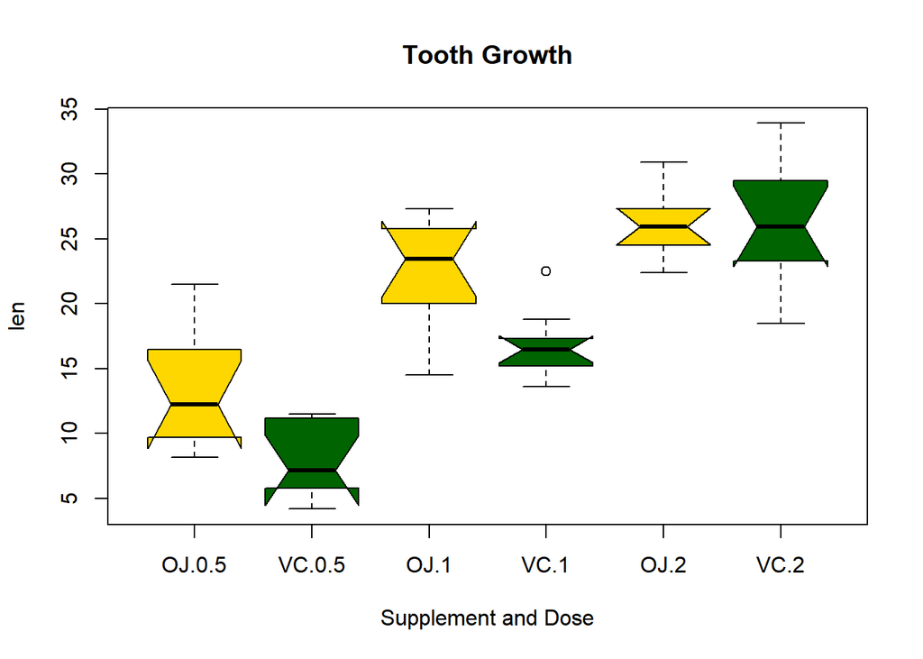

```r
# Notched Boxplot of Tooth Growth Against 2 Crossed Factors
# boxes colored for ease of interpretation
boxplot(len~supp*dose, data =  ToothGrowth, notch = TRUE,
  col = (c("gold","darkgreen")),
  main = "Tooth Growth", xlab = "Supplement and Dose")
```

In the notched boxplot, if two boxes’ notches do not overlap this is strong evidence their medians differ (Chambers et al., 1983, p. 62).

Other Options  
The boxplot.matrix( ) function in the sfsmisc package draws a boxplot for each column (row) in a matrix. The boxplot.n( ) function in the gplots package annotates each boxplot with its sample size. The bplot( ) function in the Rlab package offers many more options controlling the positioning and labeling of boxes in the output.

Violin Plots  
A violin plot is a combination of a boxplot and a kernel density plot. They can be created using the vioplot( ) function from vioplot package.

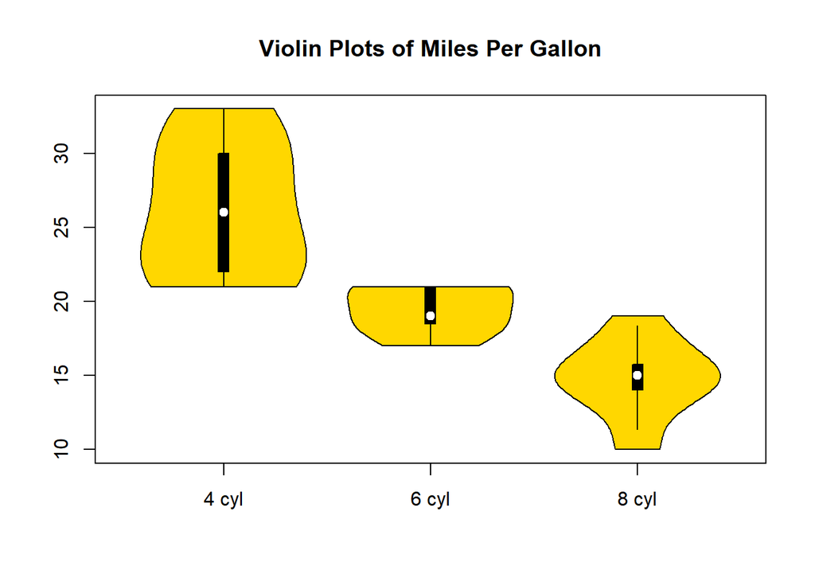

```r
# Violin Plots
if (!require("vioplot")) {install.packages("vioplot")}
library(vioplot)
x1 <- mtcars$mpg[mtcars$cyl == 4]
x2 <- mtcars$mpg[mtcars$cyl == 6]
x3 <- mtcars$mpg[mtcars$cyl == 8]
vioplot(x1, x2, x3, names = c("4 cyl", "6 cyl", "8 cyl"),
   col = "gold")
title("Violin Plots of Miles Per Gallon")
```

Bagplot - A 2D Boxplot Extension  
The bagplot(x, y) function in the aplpack package provides a bivariate version of the univariate boxplot. The bag contains 50% of all points. The bivariate median is approximated. The fence separates points in the fence from points outside. Outliers are displayed.

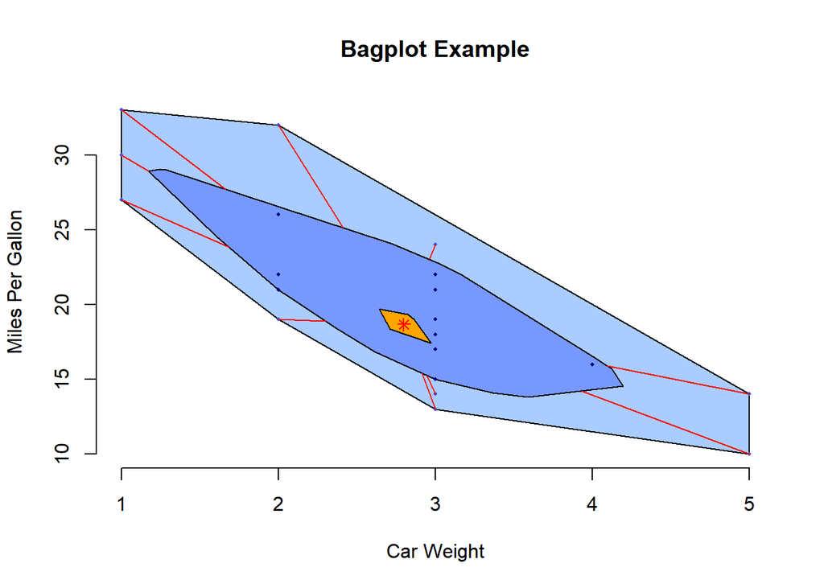

```r
# Example of a Bagplot
if (!require("aplpack")) {install.packages("aplpack")}
library(aplpack)
bagplot(wt,mpg, xlab = "Car Weight",
        ylab = "Miles Per Gallon",
        main = "Bagplot Example")
```

### Scatterplots

1. Simple Scatterplot  
   There are many ways to create a scatterplot in R. The basic function is plot(x, y), where x and y are numeric vectors denoting the (x,y) points to plot.

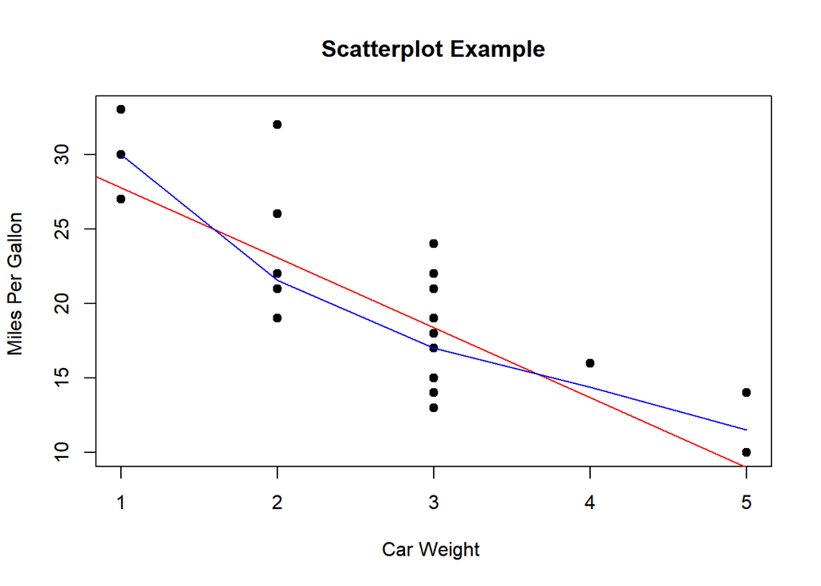

```r
# Simple Scatterplot
plot(wt, mpg, main = "Scatterplot Example",
   xlab = "Car Weight ", ylab = "Miles Per Gallon ", pch = 19)

# Add fit lines
abline(lm(mpg~wt), col = "red") # regression line (y~x)
lines(lowess(wt,mpg), col = "blue") # lowess line (x,y)
```

The *scatterplot( )* function in the **car** package offers many enhanced features, including fit lines, marginal box plots, conditioning on a factor, and interactive point identification. Each of these features is optional.

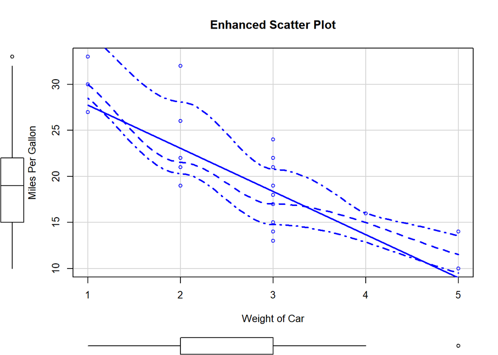

```r
# Enhanced Scatterplot of MPG vs. Weight
# by Number of Car Cylinders
library(car)
scatterplot(mpg ~ wt, data = mtcars,
   xlab = "Weight of Car", ylab = "Miles Per Gallon",
   main = "Enhanced Scatter Plot")
```

2. Scatterplot Matrices  
   There are at least 4 useful functions for creating scatterplot matrices. Analysts must love scatterplot matrices!

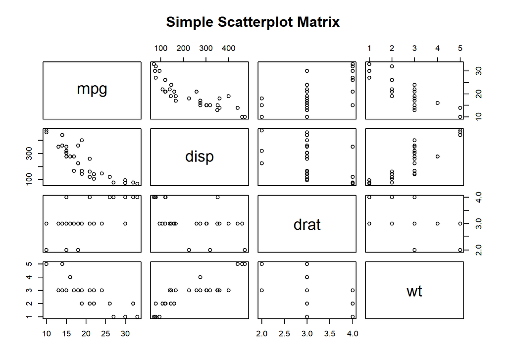

```r
# Basic Scatterplot Matrix
pairs(~mpg+disp+drat+wt,data = mtcars,
   main = "Simple Scatterplot Matrix")
```

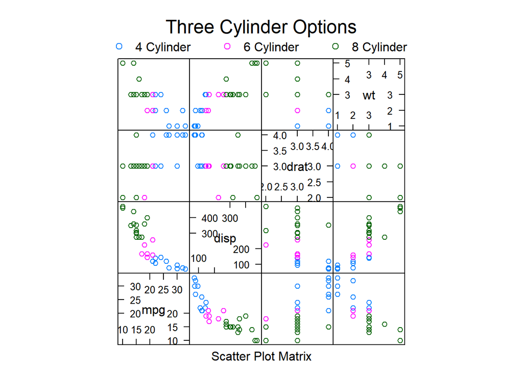

```r
# The lattice package provides options to condition the scatterplot matrix on a factor.

# Scatterplot Matrices from the lattice Package
library(lattice)
super.sym <- trellis.par.get("superpose.symbol")
splom(mtcars[c(1,3,5,6)], groups = cyl,
   panel = panel.superpose,
   key = list(title = "Three Cylinder Options",
   columns = 3,
   points = list(pch = super.sym$pch[1:3],
   col = super.sym$col[1:3]),
   text = list(c("4 Cylinder","6 Cylinder","8 Cylinder"))))
```

[output not shown]

[output not shown]

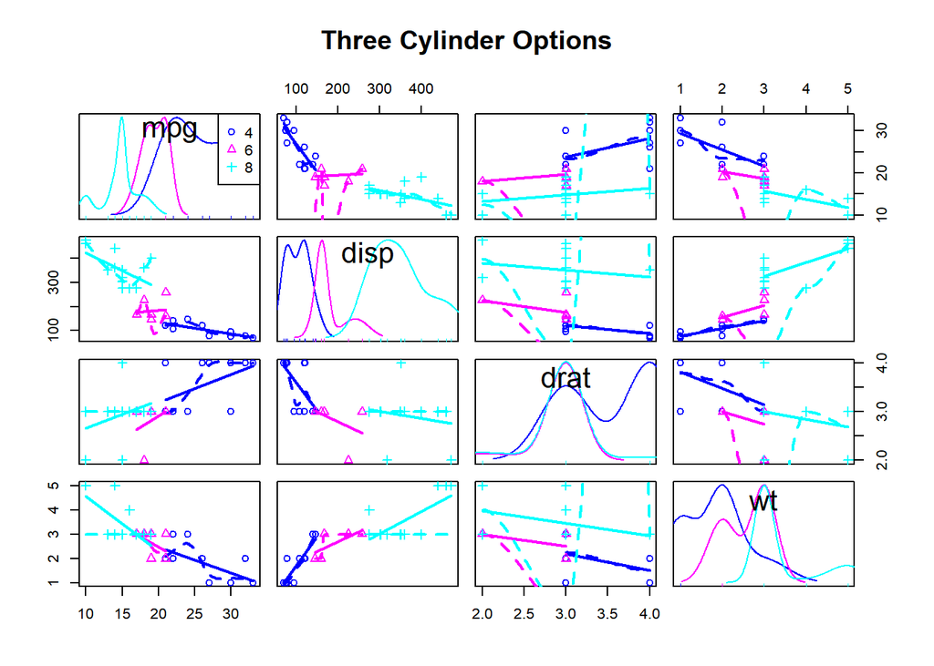

```r
# The car package can condition the scatterplot.matrix on a factor, and optionally include lowess and linear best fit lines, and boxplot, densities, or histograms in the principal diagonal, as well as rug plots in the margins of the cells.

# Scatterplot Matrices from the car Package
library(car)
scatterplotMatrix(~mpg + disp + drat + wt|cyl,
                   data = mtcars,
                   main = "Three Cylinder Options")
```

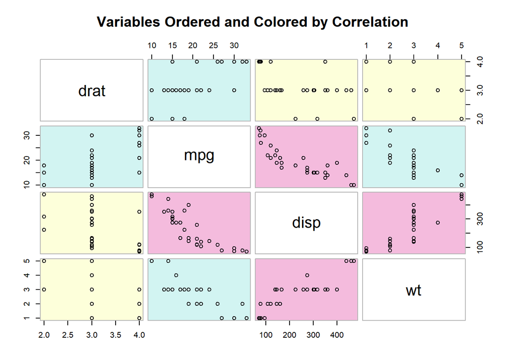

```r
# The gclus package provides options to rearrange the variables so that those with higher correlations are closer to the principal diagonal. It can also color code the cells to reflect the size of the correlations.

# Scatterplot Matrices from the glus Package
library(gclus)
dta <- mtcars[c(1,3,5,6)] # get data
dta.r <- abs(cor(dta)) # get correlations
dta.col <- dmat.color(dta.r) # get colors
# reorder variables so those with highest correlation
# are closest to the diagonal
dta.o <- order.single(dta.r)
cpairs(dta, dta.o, panel.colors = dta.col, gap = .5,
main = "Variables Ordered and Colored by Correlation" )
```

3. High Density Scatterplots  
   When there are many data points and significant overlap, scatterplots become less useful. There are several approaches that be used when this occurs. The hexbin(x, y) function in the hexbin package provides bivariate binning into hexagonal cells (it looks better than it sounds).

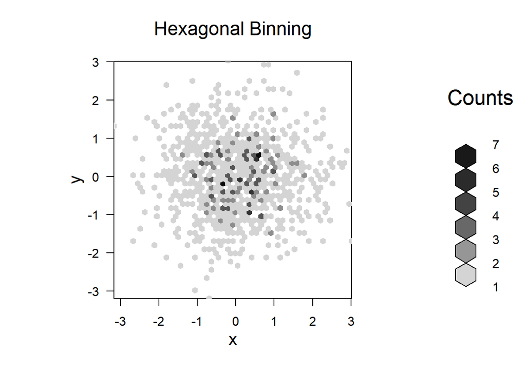

```r
# High Density Scatterplot with Binning
library(hexbin)
x <- rnorm(1000)
y <- rnorm(1000)
bin <- hexbin(x, y, xbins = 50)
plot(bin, main = "Hexagonal Binning")
```

Alternatively, *smoothScatter()* produces a smoothed color density representation of a scatterplot, obtained through a (2D) kernel density estimate.

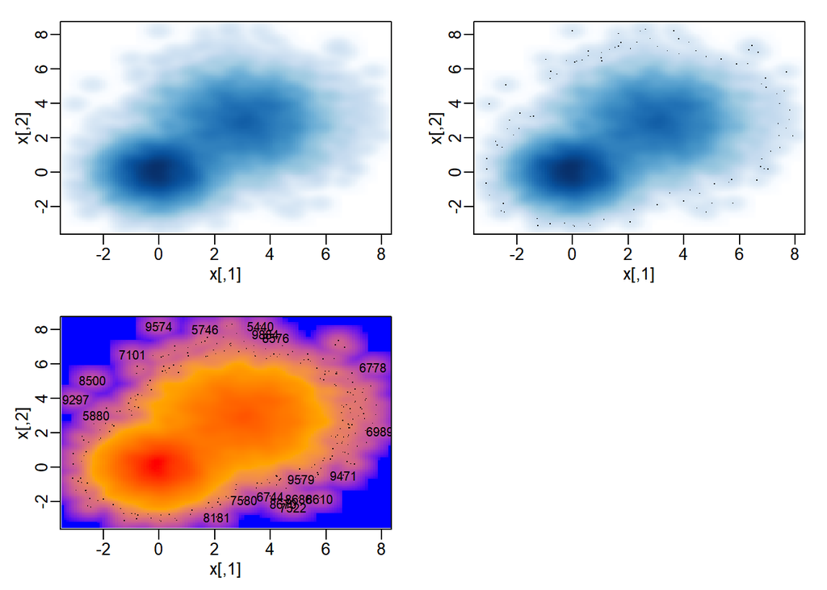

```r
n <- 10000
x1  <- matrix(rnorm(n), ncol = 2)
x2  <- matrix(rnorm(n, mean = 3, sd = 1.5), ncol = 2)
x   <- rbind(x1, x2)

oldpar <- par(mfrow = c(2, 2), mar=.1+c(3,3,1,1), mgp = c(1.5, 0.5, 0))
smoothScatter(x, nrpoints = 0)
smoothScatter(x)
## a different color scheme:
Lab.palette <- colorRampPalette(c("blue", "orange", "red"), space = "Lab")
i.s <- smoothScatter(x, colramp = Lab.palette,
                     ## pch=NA: do not draw them
                     nrpoints = 250, ret.selection=TRUE)
## label the 20 very lowest-density points,the "outliers" (with obs.number):
i.20 <- i.s[1:20]
text(x[i.20,], labels = i.20, cex = 0.75)
```

Another option for a scatterplot with significant point overlap is the sunflowerplot. See help(sunflowerplot) for details.

Finally, you can save the scatterplot in PDF format and use color transparency to allow points that overlap to show through (this idea comes from B.S. Everrit in HSAUR).

```r
# High Density Scatterplot with Color Transparency
pdf("scatterplot.pdf")
x <- rnorm(1000)
y <- rnorm(1000)
plot(x,y, main = "PDF Scatterplot Example",
     col = rgb(0,100,0,50, maxColorValue = 255),
     pch = 16)
dev.off()
```

Note: You can use the col2rgb( ) function to get the rbg values for R colors. For example, col2rgb(“darkgreen”) yields r = 0, g = 100, b = 0. Then add the alpha transparency level as the 4th number in the color vector. A value of zero means fully transparent. See help(rgb) for more information.

4. 3D Scatterplots  
   You can create a 3D scatterplot with the scatterplot3d package. Use the function scatterplot3d(x, y, z).

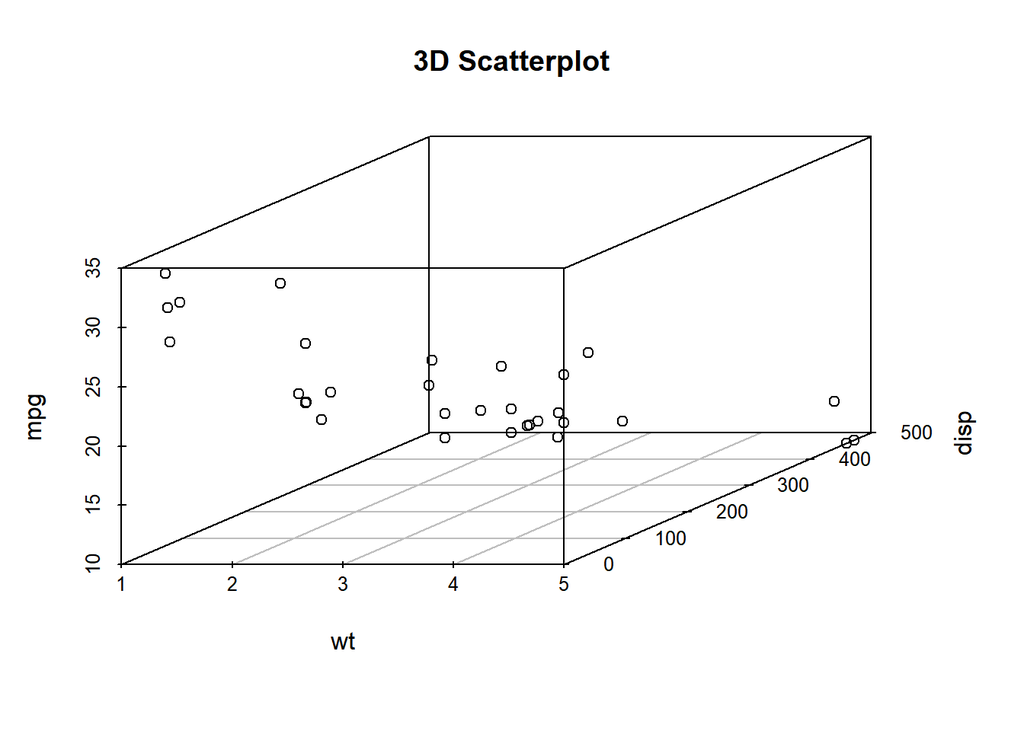

```r
# 3D Scatterplot
library(scatterplot3d)

scatterplot3d(wt,disp,mpg, main = "3D Scatterplot")
```

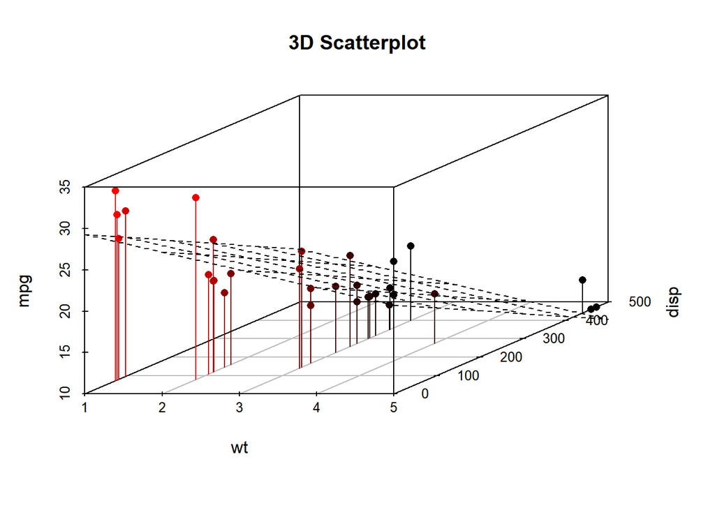

```r
# 3D Scatterplot with Coloring and Vertical Drop Lines
library(scatterplot3d)

scatterplot3d(wt,disp,mpg, pch = 16, highlight.3d = TRUE,
  type = "h", main = "3D Scatterplot")
# 3D Scatterplot with Coloring and Vertical Lines
# and Regression Plane
library(scatterplot3d)

s3d <- scatterplot3d(wt,disp,mpg, pch = 16, highlight.3d = TRUE,
  type = "h", main = "3D Scatterplot")
fit <- lm(mpg ~ wt+disp)
s3d$plane3d(fit)
```

[output not shown]

5. Spinning 3D Scatterplots  
   You can also create an interactive 3D scatterplot using the plot3D(x, y, z) function in the rgl package. It creates a spinning 3D scatterplot that can be rotated with the mouse. The first three arguments are the x, y, and z numeric vectors representing points. col = and size = control the color and size of the points respectively.

```r
# Spinning 3d Scatterplot
library(rgl)
plot3d(wt, disp, mpg, col = "red", size = 3)
```

## Graphical Parameters

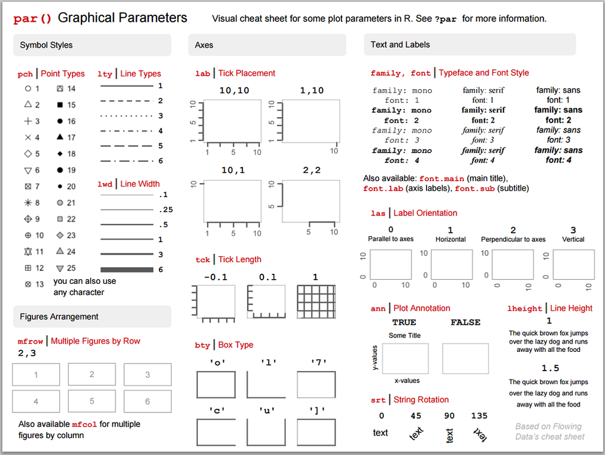

One way is to specify these options in through the par( ) function. If you set parameter values here, the changes will be in effect for the rest of the session or until you change them again. The format is par(optionname=value, optionname=value, …).

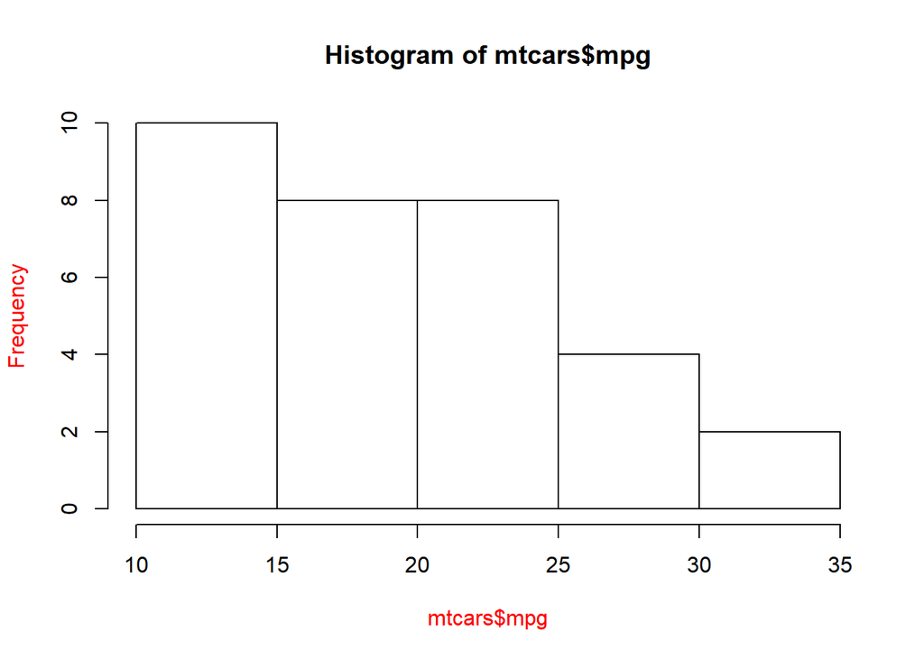

```r
# Set a graphical parameter using par()
# par()              # view current settings
suppressWarnings({
  opar <- par()     # make a copy of current settings
  par(col.lab = "red") # red x and y labels
  hist(mtcars$mpg)   # create a plot with these new settings
  par(opar)
})         # restore original settings
```

A second way to specify graphical parameters is by providing the optionname=value pairs directly to a high level plotting function. In this case, the options are only in effect for that specific graph.

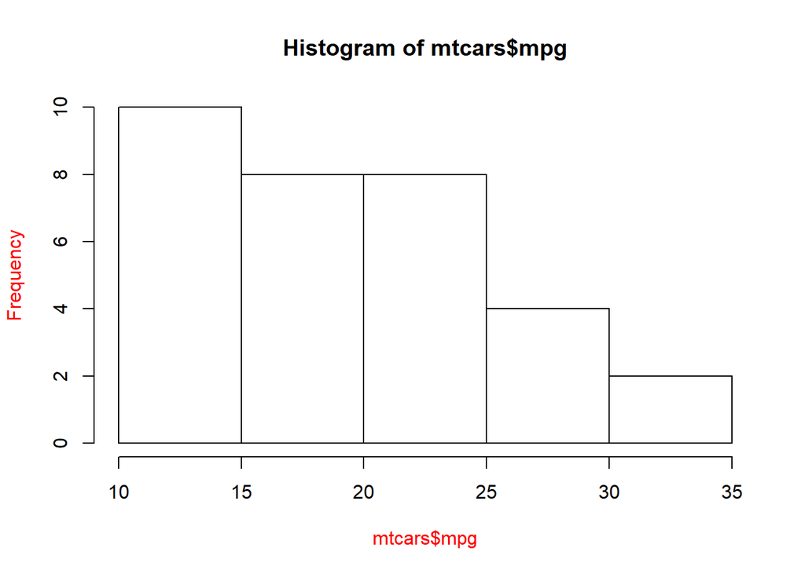

```r
# Set a graphical parameter within the plotting function
hist(mtcars$mpg, col.lab = "red")
```

See the help for a specific high level plotting function (e.g. plot, hist, boxplot) to determine which graphical parameters can be set this way.